# Prosper Loan Data Analysis

## Investigation Overview

**This Investigation walks through Loan Prosper Dataset. It aims to have a basic analysis of this dataset nature, what trends are there, what features are more important, and which give more info about Loan Status. There're many different visualizations to look at things more throughly. Finally, a summary of what've been collected.**

## Dataset Overview

**This Dataset is US Loan Prosper Dataset. There're many features, among which a few are selected for this investigation. This dataset is from Aug 2009 to March 2014. It has 100k+ records, covering most Occupations, states, Interest rates, etc.**

#### Index

- Preliminary Wrangling
- Univariate Exploration
- Bivariate Exploration
- Multivariate Exploration
- Summary

## Preliminary Wrangling

```python
import numpy as np
import pandas as pd
import matplotlib.pyplot as plt
import seaborn as sb

%matplotlib inline
```

```python
# df_full = pd.read_csv('../prosperLoanData - Full data.csv')

# cols = ['LoanStatus', 'Occupation', 'EmploymentStatus', 'BorrowerState', 'IncomeRange', 'LoanOriginationDate',
#         'BorrowerAPR', 'BorrowerRate', 'ProsperRating (numeric)', 'DebtToIncomeRatio', 'MonthlyLoanPayment', 'Term',
#         'LoanOriginalAmount', 'Recommendations', 'IsBorrowerHomeowner', 'IncomeVerifiable']

# df = df_full[cols].copy()
# df = df.dropna()
# df = df.drop_duplicates()
# df = df.sample(n=70000)
# df = df.rename(columns={'ProsperRating (numeric)':'ProsperRating'})
# df.to_csv('prosperLoanData.csv', index=False)
```

```python
df = pd.read_csv('prosperLoanData.csv')

df_cols = ['LoanStatus', 'Occupation', 'EmploymentStatus', 'BorrowerState', 'IncomeRange', 'LoanOriginationDate',
           'BorrowerAPR', 'BorrowerRate', 'ProsperRating', 'DebtToIncomeRatio', 'MonthlyLoanPayment', 'Term',
           'LoanOriginalAmount', 'Recommendations', 'IsBorrowerHomeowner', 'IncomeVerifiable']

df = df[df_cols].sample(10000)
df.LoanOriginationDate = pd.to_datetime(df.LoanOriginationDate)
```

```python
def labelingh(ax, s = 13, w_=1.05, y_=0.5):
    for p in ax.patches:
        width = p.get_width()
        x, y = p.get_xy()
        ax.annotate(f'{width:.0f}', (width*w_, y+y_), fontsize=s, va='center')

def labelingv(ax, s = 13, h_=1.05, x_=0.5):
    for p in ax.patches:
        height = p.get_height()
        x, y = p.get_xy()
        ax.annotate(f'{height:.0f}', (x+x_, height*h_), fontsize=s, ha='center')

def rand_jitter(arr, f=.01):
    stdev = f*(max(arr)-min(arr))
    return arr + np.random.randn(len(arr)) * stdev

_ = [[1*10**x,3*10**x] for x in range(5)]
log_ticks = [i for j in _ for i in j]
_ = [['%ik'%(1*10**x),'%ik'%(3*10**x)] for x in range(2)]
log_labels = [0,3,10,30,100,300]+[i for j in _ for i in j]

color = sb.color_palette()[0]
```

### What is the structure of your dataset?

LoanStatus object Occupation object EmploymentStatus object BorrowerState object IncomeRange object LoanOriginationDate object BorrowerAPR float64 BorrowerRate float64 ProsperRating float64 DebtToIncomeRatio float64 MonthlyLoanPayment float64 Term int64 LoanOriginalAmount int64 Recommendations int64 IsBorrowerHomeowner bool IncomeVerifiable bool

The data initially had 100k+ rows and 80 rows, so a subset of the data is chosen to work on, and the features of interest. The new clean data is saved in another file to upload along with source code.

The cleaning steps taken have changed the results slightly from what's expected if we used the full data, but still in our investigation and limited scope, the differences will be rather tolerable.

There're records among those contain null in some feature that have some distinct characteristics that don't share with other, and as I've eliminated rows with null values, the sample no matter how big will most likely not explain the whole and actual population, so it'd seem like sample isn't truly random. This is for clarification, as for solution it'd require to have in-depth investigation, which is probably beyond scope.

There're some categorical features, stated below in detail:

LoanStatus : Chargedoff, Completed, Current, Defaulted, FinalPaymentInProgress, PastDue, Cancelled. Last category might not appear in a small sample, as it's occurances are low.

Occupation : Among many jobs' values stated in this field, Most common is Other and Professional, there's some analysis about 'Other' against other jobs.

BorrowerState : There's data for 48 state in the sample, that might not include all states in the dataset, but that means other states have little to no help to analysis, at least on a small scale, having 'CA' as most common states.

IncomeRange : Not employed, \$1-24,999, \\$25,000-49,999, \$50,000-74,999, \\$75,000-99,999, \$100,000+. There's another Range '\\$0' which is mostly like Not employed, again its effect isn't worrisome.

There's one Datetime col, Loan Origination Date, on format 'yyyy-mm-dd'.

### What is/are the main feature(s) of interest in your dataset?

In this invistigation, main features are that give valuable info or trends, that might include the following features: LoanStatus, BorrowerAPR, BorrowerRate, LoanOriginalAmount.

### What features in the dataset do you think will help support your investigation into your feature(s) of interest?

There're a few features that to look into, starting with univariate exploration and through the end to get valuable info from a multivariate plot. It's not quite the case that everyone has some background about finance and how loans work, and so for me, so there're few features that collectively, supposedly, will give more details and clear the way for through investigation.  
Occupation, EmploymentStatus, BorrowerState, IncomeRange, BorrowerAPR, BorrowerRate, DebtToIncomeRatio, IsBorrowerHomeowner, IncomeVerifiable; these features will give some info about the borrowers and how capable are they to clear their debts. Along with LoanStatus, ProsperRating, MonthlyLoanPayment, Term, LoanOriginalAmount, Recommendations.

## Univariate Exploration

### `LoanStatus` distribution

**This shows loan status distibution. It looks like past due are few and all promising, on full-data though, there're more of past due and cancelled loans.**

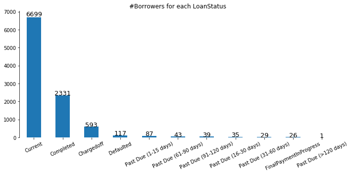

```python
count = df.LoanStatus.value_counts()

# plotting bar chart
count.plot(kind='bar', figsize=(10,5),
           title = '#Borrowers for each LoanStatus',
           legend=False, rot=25)

[plt.gca().spines[x].set_visible(False) for x in ['top', 'right', 'bottom']]
labelingv(plt.gca(), h_=1.01, x_=.25)

# plt.yscale('log'); plt.yticks(log_ticks[:8]+[7000], log_labels[:8]+['7k'])

plt.tight_layout()
```

### `Occupation` distribution

**This shows borrowers' occupation distribution.**

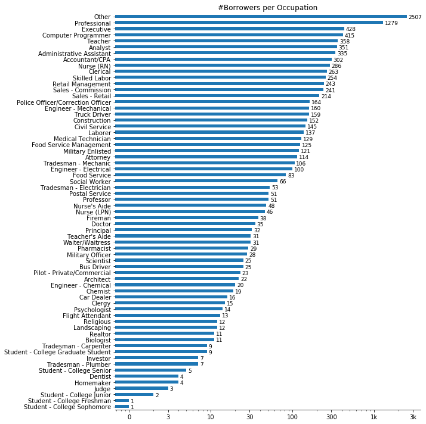

```python
count = pd.DataFrame(df.Occupation.value_counts()).sort_values('Occupation')

# plotting bar chart
count.plot(kind='barh', figsize=(10,10),
           title = '#Borrowers per Occupation',
           legend=False, rot=0)

[plt.gca().spines[x].set_visible(False) for x in ['top', 'right', 'left']]
labelingh(plt.gca(), 9, 1.05, .15)

plt.xscale('log'); plt.xticks(log_ticks[:8], log_labels[:8])

plt.tight_layout()
```

### `BorrowerState` distribution

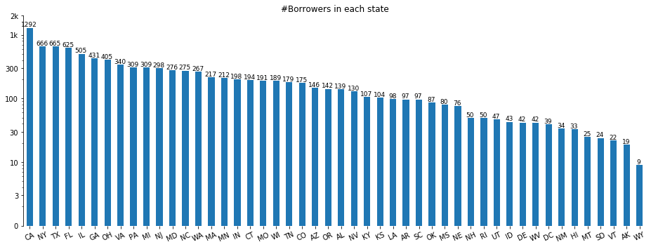

```python
count = df.BorrowerState.value_counts()

# plotting bar chart
count.plot(kind='bar', figsize=(13,5),
           title = '#Borrowers in each state',
           legend=False, rot=25)

[plt.gca().spines[x].set_visible(False) for x in ['top', 'right', 'bottom']]
labelingv(plt.gca(), 9, 1.05, .2)

plt.yscale('log'); plt.yticks(log_ticks[:7]+[2000], log_labels[:7]+['2k'])

plt.tight_layout()
```

### `IncomeRange` distribution

**This shows income annualy for borrowers. It shows that those less than $\$$25k are minimum, while most are in range $\$$25k to $\$$75k following by $\$$75k+. `Not Employed` and `$0` are choices that happens to be there in full dataset, but there's none in the sample taken, it's explained above.**

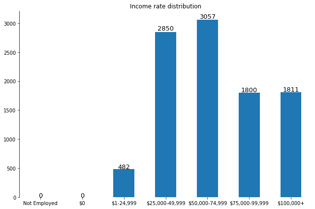

```python
range_order = ['Not Employed', '$0', '$1-24,999', '$25,000-49,999', '$50,000-74,999', '$75,000-99,999', '$100,000+']
count = df.IncomeRange.value_counts().reindex(range_order)

# plotting bar chart
count.plot(kind='bar', figsize=(9, 6),
           title = 'Income rate distribution',
           legend=False, rot=0)

[plt.gca().spines[x].set_visible(False) for x in ['top', 'right', 'bottom']]
labelingv(plt.gca(), 13, 1.01, .25)

plt.tight_layout()
```

### `BorrowerAPR` distribution

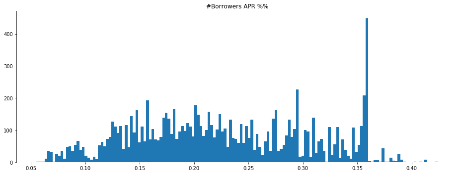

```python
# plotting histogram
df.BorrowerAPR.plot(kind='hist', bins=150, figsize=(13, 5),
                    title = '#Borrowers APR %%',
                    legend=False, rot=0)

[plt.gca().spines[x].set_visible(False) for x in ['top', 'right', 'bottom']]
plt.ylabel('')

plt.tight_layout()
```

### `BorrowerRate` distribution

**This shows borrowers ineterst rates, it shows some peaks preceeded immediatly with a fall, with peaks creating a trend all the way.**

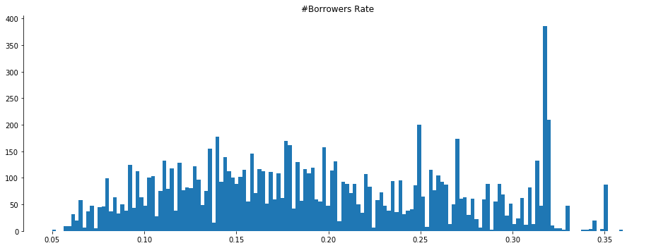

```python
# plots the bar graph
df.BorrowerRate.plot(kind='hist', bins=150, figsize=(13, 5),
                     title = '#Borrowers Rate',
                     legend=False, rot=0)

[plt.gca().spines[x].set_visible(False) for x in ['top', 'right', 'bottom']]
plt.ylabel('')

plt.tight_layout()
```

### `ProsperRating` distribution

**This shows prosper rating for borrowers. The distribution tends to normal distribution, having rate of 4 as peak or center. It's a little left-skewed where rate of 2 and 3 slightly falls off the curve**

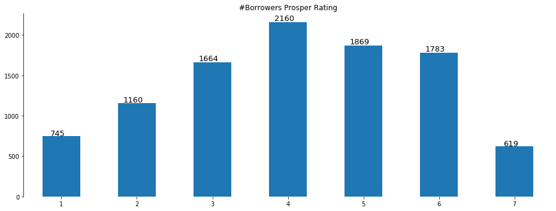

```python
range_order = [1, 2, 3, 4, 5, 6, 7]
count = df.ProsperRating.value_counts().reindex(range_order)

# plots the bar graph
count.plot(kind='bar', figsize=(13, 5),
           title = '#Borrowers Prosper Rating',
           legend=False, rot=0)

labelingv(plt.gca(), 13, 1.01, .2)
[plt.gca().spines[x].set_visible(False) for x in ['top', 'right', 'bottom']]

plt.tight_layout()
```

### `DebtToIncomeRatio` distribution

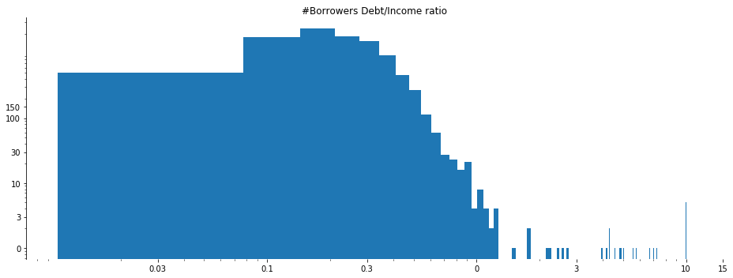

```python
# plots the bar graph
df.DebtToIncomeRatio.plot(kind='hist', bins = 150, figsize=(13, 5),
                          title = '#Borrowers Debt/Income ratio',
                          legend=False, rot=0)

plt.xscale('log'); plt.yscale('log'); plt.yticks(log_ticks[:5]+[150], log_labels[:5]+[150])
plt.xticks([.03, .1, .3]+log_ticks[:3]+[15], [.03, .1, .3]+log_labels[:3]+[15])

[plt.gca().spines[x].set_visible(False) for x in ['top', 'right', 'bottom']]
plt.ylabel('')

plt.tight_layout()
```

### `MonthlyLoanPayment` distribution

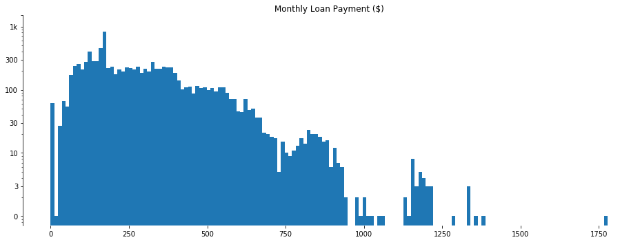

```python
# plots the bar graph
df.MonthlyLoanPayment.plot(kind='hist', bins = 150, figsize=(13, 5),
                           title = 'Monthly Loan Payment ($)',
                           legend=False, rot=0)

plt.yscale('log'); plt.yticks(log_ticks[:7]+[1500], log_labels[:7]+[''])
plt.ylabel('')
[plt.gca().spines[x].set_visible(False) for x in ['top', 'right', 'bottom']]

plt.tight_layout()
```

### `LoanOriginalAmount` distribution

**This shows frequency of Loan amount when originated. There shows some peaks at multiple for $\$$5k like, $\$$15k, $\$$20k, $\$$25k, etc. That means most borrowers loan for rather a big sum, with some loans at different amounts in between.**

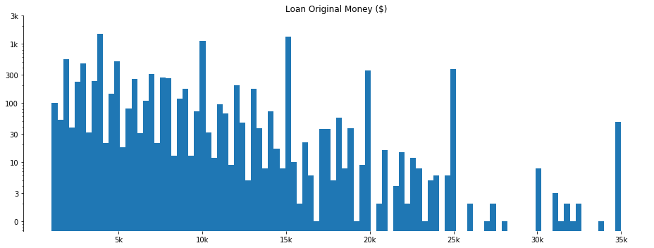

```python
# plotting bar chart
df.LoanOriginalAmount.plot(kind='hist', bins=100, figsize=(13, 5),
                      title = 'Loan Original Money ($)',
                      legend=False, rot=0)

plt.yscale('log'); plt.yticks(log_ticks[:8], log_labels[:8])
plt.xticks([5000, 10000, 15000, 20000, 25000, 30000, 35000],
           ['5k', '10k', '15k', '20k', '25k', '30k', '35k'])

plt.ylabel('')
[plt.gca().spines[x].set_visible(False) for x in ['top', 'right', 'bottom']]

plt.tight_layout()
```

### `Term` distribution

**This shows how many borrowers chose different loan terms. It shows that 36 month is most common choice, with 60 month following. This isn't surprised since borrowers tend to loan for a big sum, so it could likely be burdensome.**

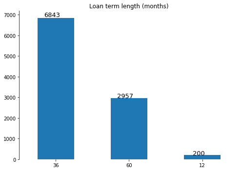

```python
count = df.Term.value_counts()

# plotting bar chart
count.plot(kind='bar', figsize=(7, 5),
                  title = 'Loan term length (months)',
                  legend=False, rot=0)

# plt.yscale('log'); plt.yticks(log_ticks[:7]+[2000], log_labels[:7]+['2k'])
labelingv(plt.gca(), 13, 1.01, .2)
[plt.gca().spines[x].set_visible(False) for x in ['top', 'right', 'bottom']]

plt.tight_layout()
```

### `Recommendations` distribution

**This discuss how many recommendations each borrower have got on their loan. It's clear here that it's actually special to have a recommendation, not to mention more than one. So it might not have strong affect eventually.**

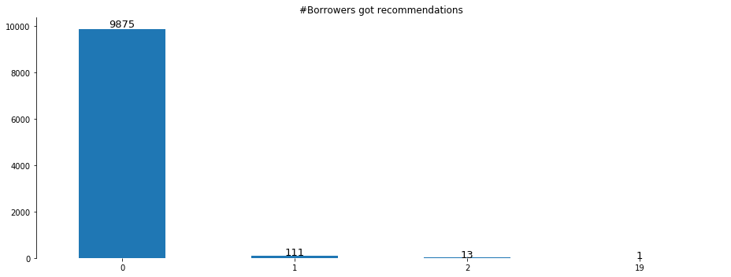

```python
count = df.Recommendations.value_counts()

# plotting bar chart
count.plot(kind='bar', figsize=(13, 5),
           title = '#Borrowers got recommendations',
           legend=False, rot=0)

labelingv(plt.gca(), 13, 1.01, .25)
[plt.gca().spines[x].set_visible(False) for x in ['top', 'right', 'bottom']]

plt.tight_layout()
```

### `IsBorrowerHomeowner` distribution

**This discuss how many borrowers actually own their home, as it might be indicatation as capability of paying their loans stably. Both groups are equally distributed nearly, further we'll see if this actually affects loan status.**

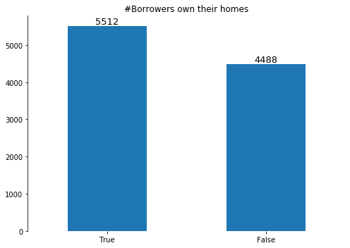

```python
count = df.IsBorrowerHomeowner.value_counts()

# plotting bar chart
count.plot(kind='bar', figsize=(7, 5),
           title = '#Borrowers own their homes',
           legend=False, rot=0)

labelingv(plt.gca(), 13, 1.01, .25)
[plt.gca().spines[x].set_visible(False) for x in ['top', 'right', 'bottom']]

plt.tight_layout()
```

### `IncomeVerifiable` distribution

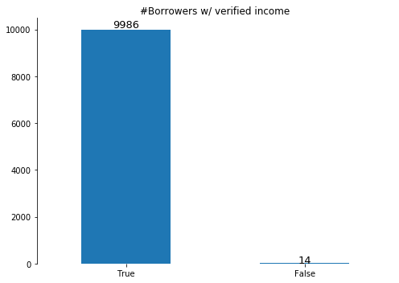

```python
states_count = df.IncomeVerifiable.value_counts()

states_count.plot(kind='bar', figsize=(7, 5),
                  title = '#Borrowers w/ verified income',
                  legend=False, rot=0)

labelingv(plt.gca(), 13, 1.01, .25)
[plt.gca().spines[x].set_visible(False) for x in ['top', 'right', 'bottom']]

plt.tight_layout()
```

### `EmploymentStatus` distribution

**This shows employment status for borrowers. It shows that majority have stable income, at least at the moment they originated the loan. It's expected since most have their income verified.**

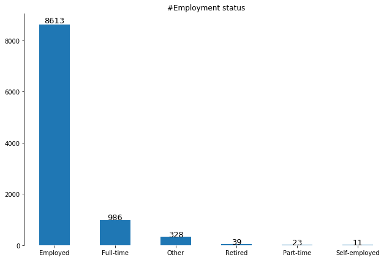

```python
count = df.EmploymentStatus.value_counts()

# plotting bar chart
count.plot(kind='bar', figsize=(9,6),
           title = '#Employment status',
           legend=False, rot=0)

# plt.yscale('log'); plt.yticks(log_ticks[:7]+[2000], log_labels[:7]+['2k'])
labelingv(plt.gca(), 13, 1.01, .25)
[plt.gca().spines[x].set_visible(False) for x in ['top', 'right', 'bottom']]

plt.tight_layout()
```

### Discuss the distribution(s) of your variable(s) of interest. Were there any unusual points? Did you need to perform any transformations?

BorrowerRate This shows borrowers ineterst rates, it shows some peaks preceeded immediatly with a fall, with peaks creating a trend all the way.

LoanOriginalAmount This shows frequency of Loan amount when originated. There shows some peaks at multiple for \$5k like, \\$15k, \$20k, \\$25k, etc. That means most borrowers loan for rather a big sum, with some loans at different amounts in between.

LoanStatus This shows loan status distibution. It looks like past due are few and all promising, on full-data though, there're more of past due and cancelled loans.

### Of the features you investigated, were there any unusual distributions? Did you perform any operations on the data to tidy, adjust, or change the form of the data? If so, why did you do this?

DebtToIncomeRatio plot is right-skewed, where there's a long tail towrads positive end, so x-lim along with log-transform would make it more apparent.

## Bivariate Exploration

### What affects the borrower’s APR or interest rate?

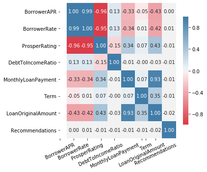

```python
plt.figure(figsize=(6,5))
sb.heatmap(sample[df_cols[6:-2]].corr(), center=0,
           vmin=-1, vmax=1, annot=True, fmt='.2f',
           cmap=sb.diverging_palette(10, 240, n=100),
           cbar_kws={"shrink": .8});

plt.xticks(rotation=25)
ticks, labels = plt.xticks()
ticks-=1
ticks[-3]+=1.3
plt.xticks(ticks, labels)
plt.ylim(8,0);

plt.tight_layout()
```

From this heatmap we can see a few linear realtions. We see there's a very strong positive relation between APR and Rate, they're nearly identical. While ProsperRating having strong negative realtion. Another strong relation between MonthlyLoanPayment and LoanOriginalAmount, which make sense and is expected.  
There's also a relation between BorrowerAPR and BorrowerRate, referred as first two, vs MonthlyLoanPayment and LoanOriginalAmount, referred as latter two, the first two both have a negative relation with latter two, we see factors are slightly similar which make sense also since both first have strong positive relation and last two have their strong positive relation, and finally PropserRating have positive relation with those latter two, and it make sense again since it has strong negative relation with both first two.

There'll be further investigation on multivariate relations.

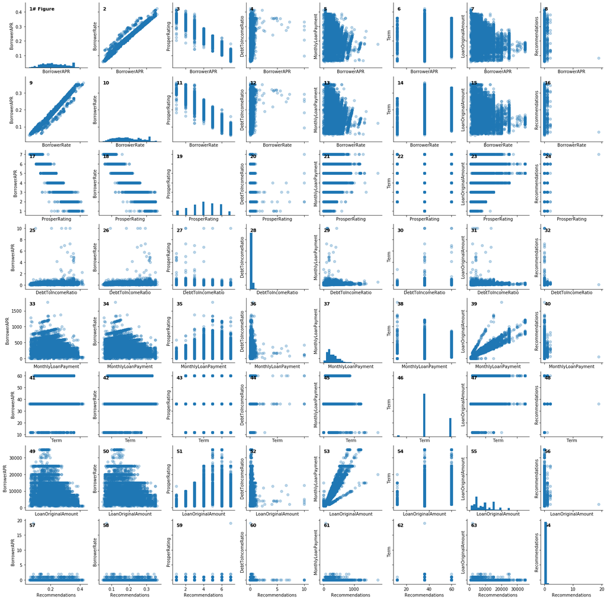

```python
g = sb.PairGrid(df, vars=df_cols[6:-2])
g = g.map_diag(plt.hist, bins=25)
g = g.map_offdiag(plt.scatter, alpha=.3)

xlabels,ylabels = [],[]

for ax in g.axes[-1,:]:
    xlabel = ax.xaxis.get_label_text()
    xlabels.append(xlabel)
for ax in g.axes[:,0]:
    ylabel = ax.yaxis.get_label_text()
    ylabels.append(ylabel)

from matplotlib.offsetbox import AnchoredText

c = 1
for i in range(len(xlabels)):
  for j in range(len(ylabels)):
    g.axes[i,j].xaxis.set_label_text(xlabels[i])
    g.axes[i,j].yaxis.set_label_text(ylabels[j])
    g.axes[i,j].add_artist(AnchoredText(str(c), prop=dict(fontweight='bold', size=11), frameon=False, loc='upper left'))
    c += 1

g.axes[0,0].add_artist(AnchoredText(f'  # Figure', prop=dict(fontweight='bold', size=11), frameon=False, loc='upper left'))
plt.show()
```

```python
def dfBi(x, y):
    dfBi = df.groupby([x,y]).count().iloc[:,0].unstack()
    if y == 'LoanStatus':
        PastDue = dfBi.iloc[:,-6:].sum(axis=1)
        PastDue.name = 'PastDue'
        drop_cols = [col for col in dfBi.iloc[0,:].keys() if 'Past Due' in col]
        dfBi.drop(drop_cols, axis=1, inplace=True)
        dfBi['PastDue'] = PastDue
    _x = df[x].value_counts()
    _x_ = _x.keys()
    for c in _x_:
        dfBi.loc[c] = dfBi.loc[c]/_x[c]
    return _x, dfBi
```

How Borrower's Occupation, Employment Status and IncomeRange affect Loan Status?  
This discuss the relation between different features of a borrower, how big the difference between borrowers and their loans' status, individually and collectively.

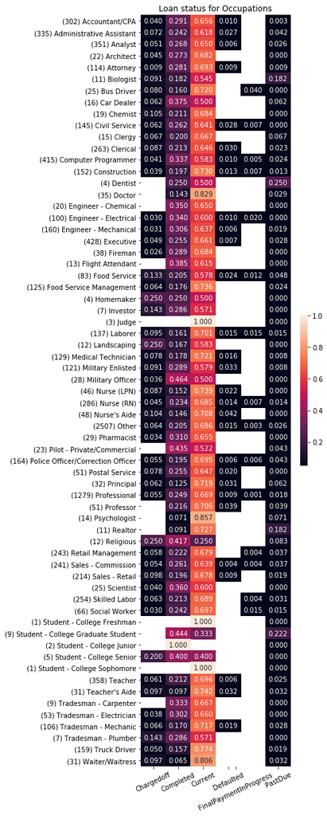

```python
x_, dfBi_ = dfBi('Occupation', 'LoanStatus')

plt.figure(figsize=(7,17))
sb.heatmap(dfBi_, vmin=0.05, vmax=1, annot=True, fmt='.3f', cbar_kws={"shrink": .2})

plt.title('Loan status for Occupations')
plt.xlabel(''); plt.ylabel('')

ticks, labels = plt.yticks()
[label.set_text('(%d) %s'%(x_[label.get_text()],label.get_text())) for label in labels]
plt.yticks(ticks, labels)
plt.ylim(dfBi_.shape[0],0)

ticks, labels = plt.xticks()
ticks[-2]-=.7
plt.xticks(ticks, labels)
plt.xticks(rotation=25)

plt.tight_layout()
```

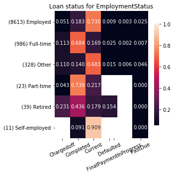

```python
x_, dfBi_ = dfBi('EmploymentStatus', 'LoanStatus')

plt.figure(figsize=(5,5))
sb.heatmap(dfBi_, vmin=0.05, vmax=1, annot=True, fmt='.3f', cbar_kws={"shrink": .8})

plt.title('Loan status for EmploymentStatus')
plt.xlabel(''); plt.ylabel('')

ticks, labels = plt.yticks()
[label.set_text('(%d) %s'%(x_[label.get_text()],label.get_text())) for label in labels]
plt.yticks(ticks, labels)
plt.yticks(rotation=0)
plt.ylim(dfBi_.shape[0],0)

ticks, labels = plt.xticks()
ticks[-2]-=.7
plt.xticks(ticks, labels)
plt.xticks(rotation=25)

plt.tight_layout()
```

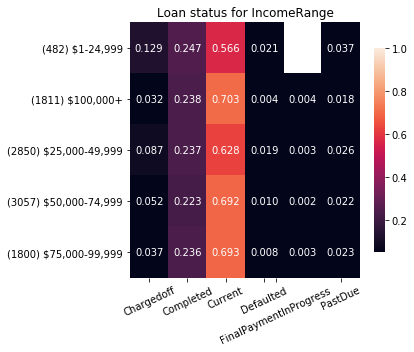

```python
x_, dfBi_ = dfBi('IncomeRange', 'LoanStatus')

plt.figure(figsize=(6,5))
sb.heatmap(dfBi_, vmin=0.05, vmax=1, annot=True, fmt='.3f', cbar_kws={"shrink": .8})

plt.title('Loan status for IncomeRange')
plt.xlabel(''); plt.ylabel('')

ticks, labels = plt.yticks()
[label.set_text('(%d) %s'%(x_[label.get_text()],label.get_text())) for label in labels]
plt.yticks(ticks, labels)
plt.ylim(dfBi_.shape[0],0)

ticks, labels = plt.xticks()
ticks[-2]-=.7
plt.xticks(ticks, labels)
plt.xticks(rotation=25)

plt.tight_layout()
```

How Borrower's State affects Loan Status?  
This discuss the relation between borrower state and loan status, maybe there're some states that have completed status or less cancelled status, and hence some relation between this state and borrowers standard of living, and it might indicate something else. Same with Occupation, EmploymentStatus, and IncomeRange.

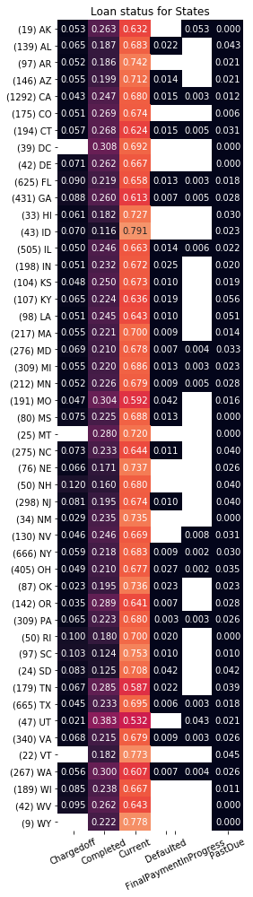

```python
x_, dfBi_ = dfBi('BorrowerState', 'LoanStatus')

plt.figure(figsize=(4,14))
sb.heatmap(dfBi_, vmin=0.05, vmax=1, annot=True, fmt='.3f', cbar=False)

plt.title('Loan status for States')
plt.xlabel(''); plt.ylabel('')

ticks, labels = plt.yticks()
[label.set_text('(%d) %s'%(x_[label.get_text()],label.get_text())) for label in labels]
plt.yticks(ticks, labels)
plt.ylim(dfBi_.shape[0],0)

ticks, labels = plt.xticks()
ticks[-2]-=.7
plt.xticks(ticks, labels)
plt.xticks(rotation=25)

plt.tight_layout()
```

How Borrower's APR and rate affect Loan Status?  
This discuss the relation between interests on loans and and their status.

```python
# _ = pd.DataFrame(df.LoanStatus.value_counts())
# PastDue = _.iloc[-7:].sum() - _.iloc[-2]
# PastDue.name = 'PastDue'
# drop_cols = [col for col in _.iloc[:,0].keys() if 'Past Due' in col]
# _.drop(drop_cols, axis=0, inplace=True)
# _ = _.append(PastDue)
# _
```

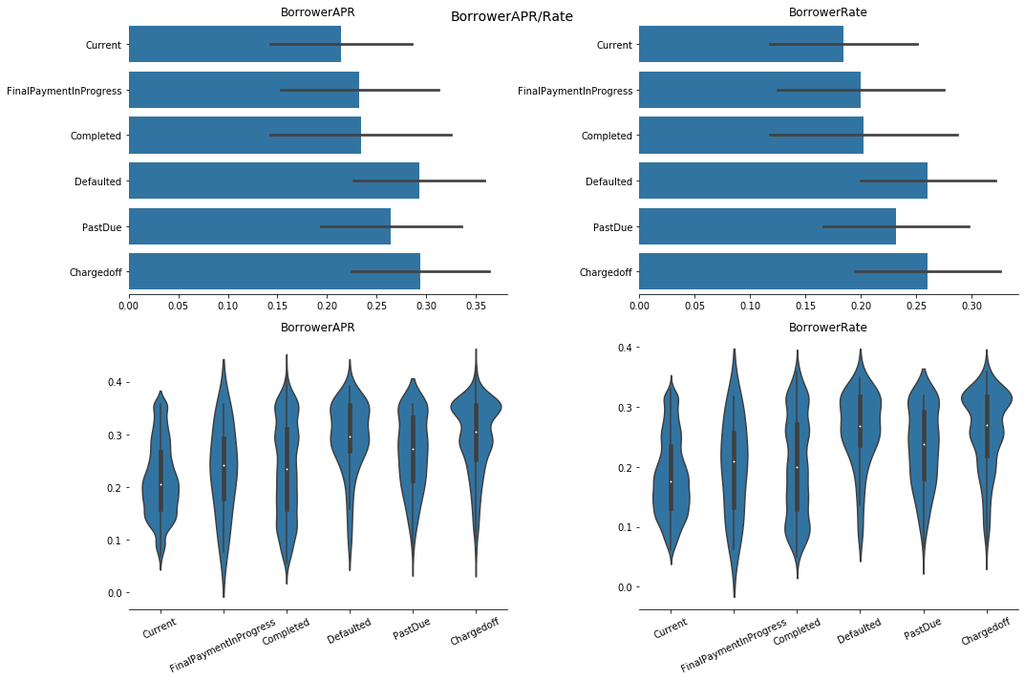

```python
fig, ax = plt.subplots(2,2, figsize=(15,10))
ax = ax.ravel()

_ = df[['BorrowerAPR', 'LoanStatus']].copy()
_.LoanStatus.replace(to_replace='Past Due.*', value='PastDue', regex=True, inplace=True)

sb.barplot(data=_, y='LoanStatus', x='BorrowerAPR',
           color=color, ci='sd', ax=ax[0])
sb.despine(left=True)

sb.violinplot(data=_, x='LoanStatus', y='BorrowerAPR',
           color=color, ci='sd', ax=ax[2])
sb.despine(left=True)

ax[0].set_title('BorrowerAPR')
ax[0].set_xlabel(''); ax[0].set_ylabel('')
ax[2].set_title('BorrowerAPR')
ax[2].set_xlabel(''); ax[2].set_ylabel('')
plt.setp(ax[2].xaxis.get_majorticklabels(), rotation=25)

_ = df[['BorrowerRate', 'LoanStatus']].copy()
_.LoanStatus.replace(to_replace='Past Due.*', value='PastDue', regex=True, inplace=True)

sb.barplot(data=_, y='LoanStatus', x='BorrowerRate',
           color=color, ci='sd', ax=ax[1])
sb.despine(left=True)

sb.violinplot(data=_, x='LoanStatus', y='BorrowerRate',
           color=color, ci='sd', ax=ax[3])
sb.despine(left=True)

ax[1].set_title('BorrowerRate')
ax[1].set_xlabel(''); ax[1].set_ylabel('')
ax[3].set_title('BorrowerRate')
ax[3].set_xlabel(''); ax[3].set_ylabel('')
plt.setp(ax[3].xaxis.get_majorticklabels(), rotation=25)

plt.suptitle('BorrowerAPR/Rate', size=14)

plt.tight_layout()
```

### BorrowerAPR / Rate change over years

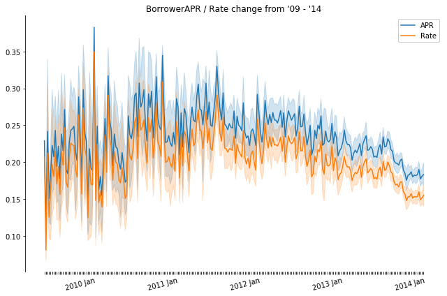

```python
_ = df[['LoanOriginationDate', 'BorrowerAPR', 'BorrowerRate']].copy()
_['Date_Week'] = _.LoanOriginationDate.dt.strftime('%Y-%W-00')

plt.figure(figsize=(9,6))

sb.lineplot(data=_, x='Date_Week', y='BorrowerAPR', label='APR')

sb.lineplot(data=_, x='Date_Week', y='BorrowerRate', label='Rate')

sb.despine(bottom=True)

plt.title('BorrowerAPR / Rate change from \'09 - \'14', size = 12)
plt.xlabel(''); plt.ylabel('')

ticks, labels = plt.xticks()
labels = ['']*23+['2010 Jan']+['']*52+['2011 Jan']+['']*52+['2012 Jan']+['']*52+['2013 Jan']+['']*52+['2014 Jan']+['']*10
plt.xticks(ticks, labels)
plt.xticks(rotation=15)

plt.legend(loc='upper right', framealpha=1)

plt.tight_layout()
```

How is the relation between DebtToIncomeRatio and LoanStatus?  
This discuss how much debt to income ratio affects a loan, like for high ratio, is it likely to be completed, due or more likely to be canceled.

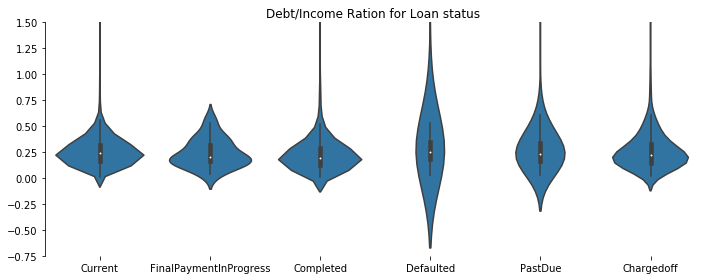

```python
_ = df[['DebtToIncomeRatio', 'LoanStatus']].copy()
_.LoanStatus.replace(to_replace='Past Due.*', value='PastDue', regex=True, inplace=True)

plt.figure(figsize=(10,4))
sb.violinplot(data=_, x='LoanStatus', y='DebtToIncomeRatio',
           color=color, ci='sd')
sb.despine(bottom=True)

plt.title('Debt/Income Ration for Loan status ')
plt.xlabel(''); plt.ylabel('')

plt.ylim(-.75,1.5)

plt.tight_layout()
```

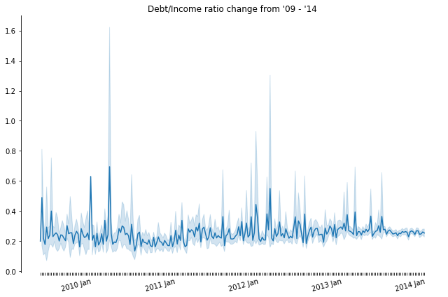

```python
_ = df[['LoanOriginationDate', 'DebtToIncomeRatio']].copy()
_['Date_Week'] = _.LoanOriginationDate.dt.strftime('%Y-%W-00')

plt.figure(figsize=(9,6))

sb.lineplot(data=_, x='Date_Week', y='DebtToIncomeRatio')

sb.despine(bottom=True)

plt.title('Debt/Income ratio change from \'09 - \'14', size = 12)
plt.xlabel(''); plt.ylabel('')

ticks, labels = plt.xticks()
labels = ['']*23+['2010 Jan']+['']*52+['2011 Jan']+['']*52+['2012 Jan']+['']*52+['2013 Jan']+['']*52+['2014 Jan']+['']*10
plt.xticks(ticks, labels)
plt.xticks(rotation=15)

plt.tight_layout()
```

How does the Term length affects Loan Status?  
This discuss if the longer Term is, the more likely we'll find more completed or even due, or it's the opposite.

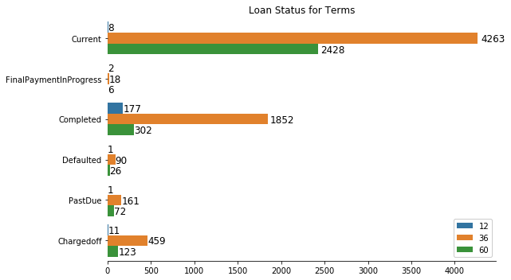

```python
_ = df[['Term', 'LoanStatus']].copy()
_.LoanStatus.replace(to_replace='Past Due.*', value='PastDue', regex=True, inplace=True)

plt.figure(figsize=(9, 5))
sb.countplot(data=_, y='LoanStatus', hue='Term')
labelingh(plt.gca(), 12, 1.01, .15)
sb.despine(left=True)

plt.title('Loan Status for Terms')
plt.xlabel(''); plt.ylabel('')
plt.legend(loc='lower right', framealpha=1)

plt.tight_layout()
```

Are homeowners are likely to complete their loans?  
This discuss the relation between IsHomeOwner and LoanStatus, and see if this, on general, means likely to complete their loans.

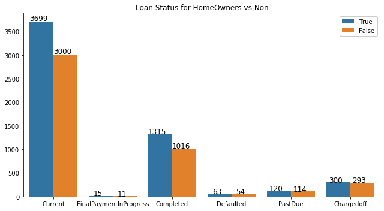

```python
_ = df[['IsBorrowerHomeowner', 'LoanStatus']].copy()
_.LoanStatus.replace(to_replace='Past Due.*', value='PastDue', regex=True, inplace=True)

plt.figure(figsize=(9, 5))
sb.countplot(data=_, x='LoanStatus', hue='IsBorrowerHomeowner', hue_order=[True, False])
labelingv(plt.gca(), 12, 1.01, .15)
sb.despine(bottom=True)

plt.title('Loan Status for HomeOwners vs Non')
plt.xlabel(''); plt.ylabel('')
plt.legend(loc='upper right', framealpha=1)

plt.tight_layout()
```

### What factors affect a loan’s outcome status?

**Through the last few viusaliztions, we've seen plots depicting some point about Loan status. It's certainly not the whole story, but from this simple analysis it's possible to conclude some facts, or relations. Though, these relations are linear relations or seemingly intuitive.**

**Borrower APR/Rate for better results, likely to be at +ve ~0.2 - ~0.3, the better the worse likely, with some exceptions.**  
**Debt/Income ratio, also for better results likely to be +ve ~0.2 or lower, with some positive results at lower ~0.**  
**HomeOwners are likely to have better results, or the least not for worst.**

### Are there differences between loans depending on how large the original loan amount was?

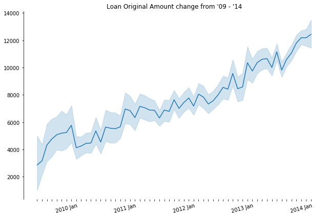

```python
_ = df[['LoanOriginationDate', 'LoanOriginalAmount']].copy()
_['Date_Month'] = _.LoanOriginationDate.dt.strftime('%Y-%m-01')

plt.figure(figsize=(9,6))

sb.lineplot(data=_, x='Date_Month', y='LoanOriginalAmount', )

sb.despine(bottom=True)

plt.title('Loan Original Amount change from \'09 - \'14', size = 12)
plt.xlabel(''); plt.ylabel('')

ticks, labels = plt.xticks()
labels = ['']*6+['2010 Jan',]+['']*11+['2011 Jan',]+['']*11+['2012 Jan',]+['']*11+['2013 Jan',]+['']*11+['2014 Jan',]+['']*2
plt.xticks(ticks, labels)
plt.xticks(rotation=15)

plt.tight_layout()
```

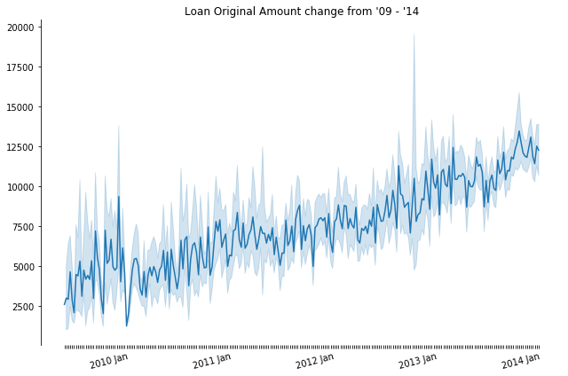

```python
_ = df[['LoanOriginationDate', 'LoanOriginalAmount']].copy()
_['Date_Week'] = _.LoanOriginationDate.dt.strftime('%Y-%W-00')

plt.figure(figsize=(9,6))

sb.lineplot(data=_, x='Date_Week', y='LoanOriginalAmount', )

sb.despine(bottom=True)

plt.title('Loan Original Amount change from \'09 - \'14', size = 12)
plt.xlabel(''); plt.ylabel('')

ticks, labels = plt.xticks()
labels = ['']*23+['2010 Jan']+['']*52+['2011 Jan']+['']*52+['2012 Jan']+['']*52+['2013 Jan']+['']*52+['2014 Jan']+['']*10
plt.xticks(ticks, labels)
plt.xticks(rotation=15)

plt.tight_layout()
```

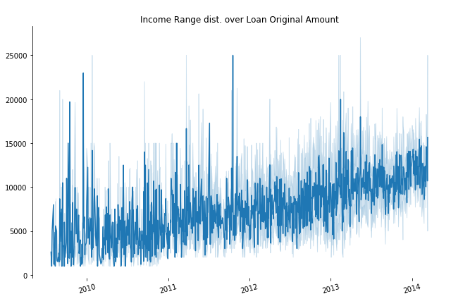

```python
_ = df[['LoanOriginationDate', 'LoanOriginalAmount']].copy()

plt.figure(figsize=(9,6))

sb.lineplot(data=_, x='LoanOriginationDate', y='LoanOriginalAmount')

sb.despine(bottom=True)

plt.title('\nIncome Range dist. over Loan Original Amount', size = 12)
plt.xlabel(''); plt.ylabel('')
plt.xticks(rotation=15)

plt.tight_layout()
```

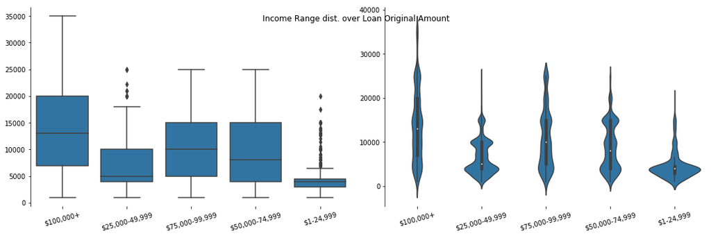

```python
_ = df[['IncomeRange', 'LoanOriginalAmount']].copy()

fig, ax = plt.subplots(1,2,figsize=(15,5))
sb.boxplot(data=_, x='IncomeRange', y='LoanOriginalAmount', color=color, ax=ax[0])
ax[0].set_xlabel(''); ax[0].set_ylabel('')
plt.setp(ax[0].xaxis.get_majorticklabels(), rotation=15)

sb.violinplot(data=_, x='IncomeRange', y='LoanOriginalAmount', color=color, ax=ax[1])
ax[1].set_xlabel(''); ax[1].set_ylabel('')
plt.setp(ax[1].xaxis.get_majorticklabels(), rotation=15)

plt.suptitle('\nIncome Range dist. over Loan Original Amount', size = 12)

sb.despine(bottom=True)

plt.tight_layout()
```

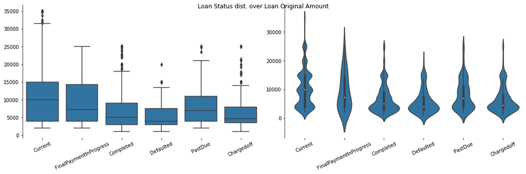

```python
_ = df[['LoanStatus', 'LoanOriginalAmount']].copy()
_.LoanStatus.replace(to_replace='Past Due.*', value='PastDue', regex=True, inplace=True)

fig, ax = plt.subplots(1,2,figsize=(15,5))
sb.boxplot(data=_, x='LoanStatus', y='LoanOriginalAmount', color=color, ax=ax[0])
ax[0].set_xlabel(''); ax[0].set_ylabel('')
plt.setp(ax[0].xaxis.get_majorticklabels(), rotation=25)

sb.violinplot(data=_, x='LoanStatus', y='LoanOriginalAmount', color=color, ax=ax[1])
ax[1].set_xlabel(''); ax[1].set_ylabel('')
plt.setp(ax[1].xaxis.get_majorticklabels(), rotation=25)

plt.suptitle('Loan Status dist. over Loan Original Amount', size = 12)

sb.despine(bottom=True)

plt.tight_layout()
```

**Through this exploration, there's been visualizations discuss Loan Status. This one above depicts Loan Original Money vs Loan Status, it's not clear if there's really some amount that acts as a threshold on either sides. It make sense there's wide range of borrowers from different classes, so it'd be better to visualize how it looke like for different Income Range and different Loan Status distirbution of Loan Original Amount, which is a multivariate plot. Also, Income Range vs Loan Original Amount shows that, indeed, borrowers with higher level income originate loans with higher amount, which is only possible with their high Income that make Debt/Income ratio lower, which is safety sign for lenders. Aside from this we saw that Loan Orignal Amount has as distribution full of spikes. That being said, the trend we see, give an indication that people needs' are growing or, on general, people imporving their income , or maybe, inflation.**

### Talk about some of the relationships you observed in this part of the investigation. How did the feature(s) of interest vary with other features in the dataset?

How Borrower's Occupation, Employment Status and IncomeRange affect Loan Status?  
This discuss the relation between different features of a borrower, how big the difference between borrowers and their loans' status, individually and collectively.

How Borrower's State affects Loan Status?  
This discuss the relation between borrower state and loan status, maybe there're some states that have completed status or less cancelled status, and hence some relation between this state and borrowers standard of living, and it might indicate something else. Same with Occupation, EmploymentStatus, and IncomeRange.

How Borrower's APR and rate affect Loan Status?  
This discuss the relation between interests on loans and and their status.

How is the relation between DebtToIncomeRatio and LoanStatus?  
This discuss how much debt to income ratio affects a loan, like for high ratio, is it likely to be completed, due or more likely to be canceled.

How does the Term length affects Loan Status?  
This discuss if the longer Term is, the more likely we'll find more completed or even due, or it's the opposite.

Are homeowners are likely to complete their loans?  
This discuss the relation between IsHomeOwner and LoanStatus, and see if this, on general, means likely to complete their loans.

### Did you observe any interesting relationships between the other features (not the main feature(s) of interest)?

Discuss relation between Loan Original Amount against few factors, Prosper Rating representing and debt/income ratio and monthly payment and length in months, further analysis including three or more variables and more complicated relation might be more useful.

## Multivariate Exploration

### Loan Status vs Income Range vs Loan Original Amount

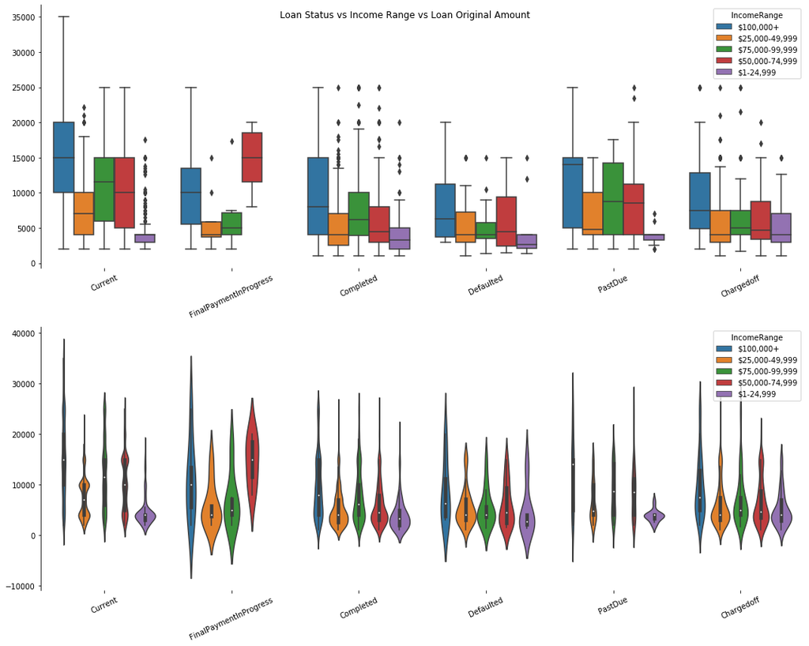

```python
_ = df[['LoanStatus', 'LoanOriginalAmount', 'IncomeRange']].copy()
_.LoanStatus.replace(to_replace='Past Due.*', value='PastDue', regex=True, inplace=True)

fig, ax = plt.subplots(2,1,figsize=(15,12))
sb.boxplot(data=_, x='LoanStatus', y='LoanOriginalAmount', hue='IncomeRange', ax=ax[0])
ax[0].set_xlabel(''); ax[0].set_ylabel('')
plt.setp(ax[0].xaxis.get_majorticklabels(), rotation=25)

sb.violinplot(data=_, x='LoanStatus', y='LoanOriginalAmount', hue='IncomeRange', ax=ax[1])
ax[1].set_xlabel(''); ax[1].set_ylabel('')
plt.setp(ax[1].xaxis.get_majorticklabels(), rotation=25)

plt.suptitle('Loan Status vs Income Range vs Loan Original Amount', size = 12)

sb.despine(bottom=True)

plt.tight_layout()
```

**In the last plot about Loan Original Amount vs Loan Status, mentioned that we need a multivariate plot that explains the Loan Original Amount for different Loan status at each Income Range, so we can be clear that there's a limit for borrows within Income Ranges that can't exceed.**